# Stat 744 synthesis

14:29 03 December 2015

## Dynamic models

- subset of *hierarchical models* with sequential structure
- all about conditioning on/integrating over latent variables (unobserved nodes)
- handle high-dimensional integration by approximation or stochastic sampling
- sequential (e.g. Kalman, PF) vs. non-sequential methods (general MC)

## frequentist 'vs.' Bayesian

### frequentist

- estimation: direct MLE (no latent variables), Kalman filter, data cloning, IF2, synthetic likelihood, MCEM
- point estimates: MLE
- inference: Wald, profile confidence intervals (bootstrapping)
- no (top-level) priors
- tools: `pomp`, `synlik`, `NIMBLE`

## what's needed: generally

- forward simulation/likelihood for process (pomp: `rmeasure`/`dmeasure`)
- simulation/likelihood for observation (pomp: `dobservation`/`robservation`)

e.g.

\[ y_{t+1} \sim N(y_t,\sigma^2) \]

vs.

\[ {\cal L}(y_{t+1}|y_t,\sigma^2) \]

"plug and play": only need `rmeasure`, not `dmeasure`

## what's needed: specifically

- ABC, synthetic likelihood: only process + summary statistics
- particle filtering: simulate process, likelihood for (obs|process)
- MCMC, data cloning, MCEM:  
  conditional likelihoods of every node

## Hamiltonian MCMC

Three critical tricks:

- Hamiltonian MCMC
- automatic differentiation
- 'no-U-turn' sampler (NUTS)

Implementations in: Stan, TMB, PyMC

## Hamiltonian MCMC

- physical interpretation
  - "position" = set of parameter values
  - "momentum" = velocity*mass (chosen randomly)
  - "kinetic energy"
  - "potential energy": \(-\log(P)\)
- discrete steps according to Hamiltonian equations
  - reversible, volume-preserving, etc.
  - *automatically* handles correlations among variables
- continuous distributions only
- need gradient calculation

## Hamiltonian MCMC: updates

- need to choose update: "leapfrog"  
  (change momentum by \(\epsilon/2\), position by \(\epsilon\), momentum by \(\epsilon/2\))
- still need to pick step size: *No-U-Turn Sampler* (NUTS)

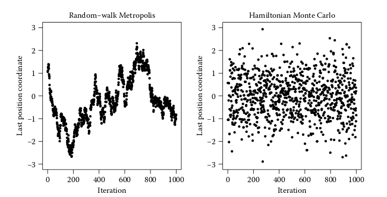

## general tools

Mix and match!

## Software

- formula interface (INLA, `dynlm`, Kalman filters) vs. write-your-own model
- write-your-own:
  - BUGS language (JAGS, NIMBLE, data cloning)
  - variations on C++ (Stan, TMB)
  - R or C++ (`synlik`, `abc`)
- limitations of software
  - broader classes of models \(\to\) write-your-own
- value of software diversity/multiple implementations

## limiting factors

- data
- algorithms
- implementations
- computation time

Need *general* building blocks …